# Multiclass logistic regression

Milica Cudina

For a similar analysis, look at this [tutorial](https://stats.oarc.ucla.edu/r/dae/multinomial-logistic-regression/) from UCLA. For more about `glmnet`, consult this [tutorial](https://glmnet.stanford.edu/articles/glmnet.html#multinomial-regression-family-multinomial) by Trevor Hastie.

First, we import the data.

```r
data<-read.csv("hsbdemo.csv")
View(data)
data
```

| X | id | female | ses | schtyp | prog | read | write | math | science | socst | honors | awards | cid |
| --- | --- | --- | --- | --- | --- | --- | --- | --- | --- | --- | --- | --- | --- |
| 1 | 45 | female | low | public | vocation | 34 | 35 | 41 | 29 | 26 | not enrolled | 0 | 1 |
| 2 | 108 | male | middle | public | general | 34 | 33 | 41 | 36 | 36 | not enrolled | 0 | 1 |
| 3 | 15 | male | high | public | vocation | 39 | 39 | 44 | 26 | 42 | not enrolled | 0 | 1 |
| 4 | 67 | male | low | public | vocation | 37 | 37 | 42 | 33 | 32 | not enrolled | 0 | 1 |
| 5 | 153 | male | middle | public | vocation | 39 | 31 | 40 | 39 | 51 | not enrolled | 0 | 1 |
| 6 | 51 | female | high | public | general | 42 | 36 | 42 | 31 | 39 | not enrolled | 0 | 1 |
| 7 | 164 | male | middle | public | vocation | 31 | 36 | 46 | 39 | 46 | not enrolled | 0 | 1 |
| 8 | 133 | male | middle | public | vocation | 50 | 31 | 40 | 34 | 31 | not enrolled | 0 | 1 |
| 9 | 2 | female | middle | public | vocation | 39 | 41 | 33 | 42 | 41 | not enrolled | 0 | 1 |
| 10 | 53 | male | middle | public | vocation | 34 | 37 | 46 | 39 | 31 | not enrolled | 0 | 1 |

[output cut: 90 more lines]

The data set contains variables on $200$ students. We will focus on a small subset of predictors. The predictor variables will be social economic status `ses` (a three-level categorical variable) and writing score `write` (a quantitative variable). The outcome variable is program type `prog` (a three-level categorical variable). Since I am interested in just this subset, I will create a smaller data frame to analyze.

```r
df=data.frame(data$ses, data$write, data$prog)
colnames(df)<-c("ses", "write", "prog")
attach(df)
```

Some exploratory data analysis is called for. The first idea is, probably to try the `plot` command.

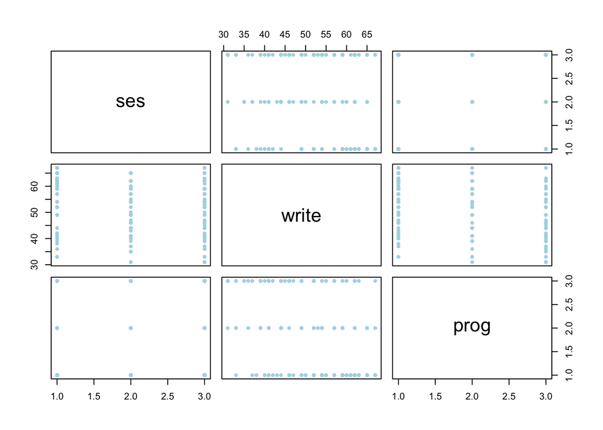

```r
plot(df,
     pch=20, col="lightblue")
```

As we can see, this is not too useful. To look at the *association* between `ses` and `prog`, a two-way table might do the trick.

```r
tab=table(ses, prog)
tab
```

```
##         prog
## ses      academic general vocation
##   high         42       9        7
##   low          19      16       12
##   middle       44      20       31
```

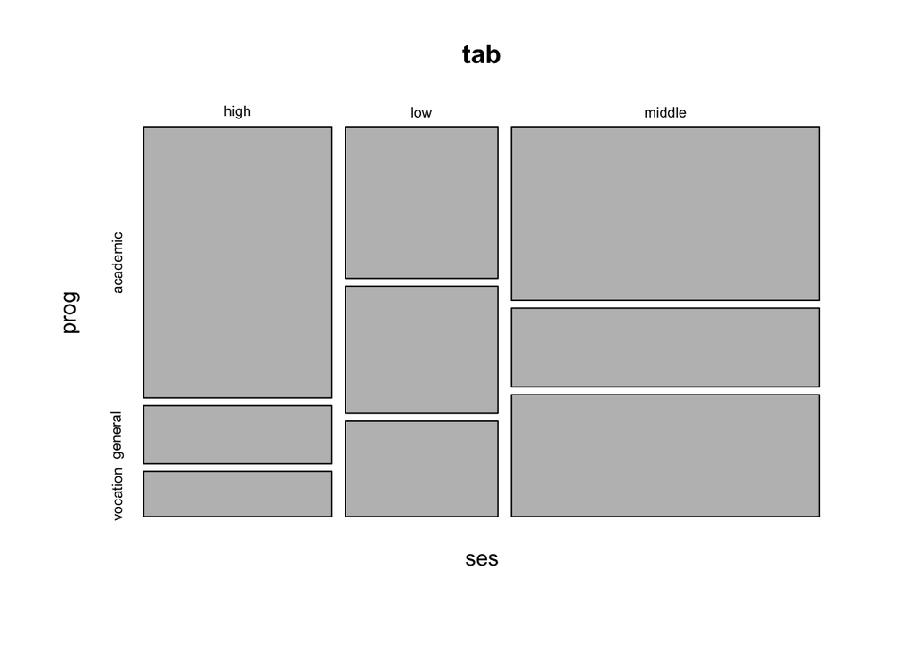

```r
mosaicplot(tab)
```

Which test might we use to test the independence hypothesis?

```r
chi2<-chisq.test(tab)
chi2
```

```
##
##  Pearson's Chi-squared test
##
## data:  tab
## X-squared = 16.604, df = 4, p-value = 0.002307
```

What about the association between the writing score and the program type?

Side-by-side boxplots might give insight.

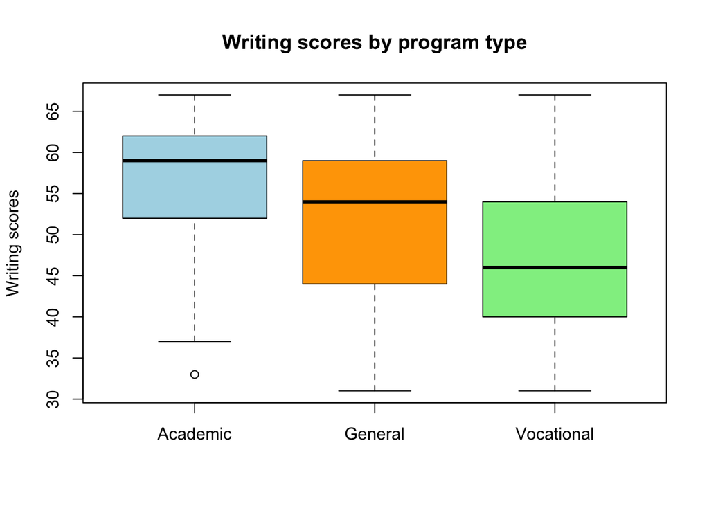

```r
write.ac=write[which(prog=="academic")]
write.gen=write[which(prog=="general")]
write.voc=write[which(prog=="vocation")]

boxplot(write.ac,write.gen, write.voc,
  main = "Writing scores by program type",
  ylab = "Writing scores",
  names = c("Academic", "General", "Vocational"),
  col=c("lightblue", "orange", "lightgreen")
)
```

We see that there is an association, but we will learn more about the extent of the effect if we run a multiclass logistic regression.

## `multinom`

Out first option is the `multinom` implementation in the `nnet` package.

```r
#install.packages("nnet")
library(nnet)
```

This implementation requires of us to set a *baseline* level for the response variable.

```r
df$prog<-as.factor(df$prog)
df$prog.base <- relevel(df$prog, ref = "academic")
```

Now, we can run the `multinom` function.

```r
mn.fit<-multinom(prog.base ~ ses + write, data=df)
```

Here is what the object `mn.fit` looks like:

```r
summary(mn.fit)
```

```
## Call:
## multinom(formula = prog.base ~ ses + write, data = df)
##
## Coefficients:
##          (Intercept)    seslow sesmiddle       write
## general     1.689478 1.1628411 0.6295638 -0.05793086
## vocation    4.235574 0.9827182 1.2740985 -0.11360389
##
## Std. Errors:
##          (Intercept)    seslow sesmiddle      write
## general     1.226939 0.5142211 0.4650289 0.02141101
## vocation    1.204690 0.5955688 0.5111119 0.02222000
##
## Residual Deviance: 359.9635
## AIC: 375.9635
```

Importantly, the coefficients above are **different** from the coefficients one sees in our textbook. However, let us look at the fitted probabilities for our data set.

```r
fitted.ps <- fitted(mn.fit)
fitted.ps
```

```
##      academic    general   vocation
## 1   0.1482721 0.33825094 0.51347695
## 2   0.1201988 0.18063349 0.69916776
## 3   0.4186768 0.23681368 0.34450947
## 4   0.1726839 0.35084330 0.47647284
## 5   0.1001206 0.16894278 0.73093666
## 6   0.3533583 0.23780466 0.40883700
## 7   0.1562526 0.19735515 0.64639223
## 8   0.1001206 0.16894278 0.73093666
## 9   0.2331247 0.22040133 0.54647393
## 10  0.1699365 0.20255764 0.62750590
## 11  0.2777676 0.37620933 0.34602312
## 12  0.2917517 0.23361220 0.47463615
## 13  0.1071652 0.30822610 0.58460873
## 14  0.2888732 0.22953872 0.48158807
```

[output cut: 20 more lines]

Also importantly, we do not have $p-$values reported above. We can figure them out easily, though.

```r
z.scores<- summary(mn.fit)$coefficients/summary(mn.fit)$standard.errors
p.val=2*(1-pnorm(abs(z.scores)))
p.val
```

```
##           (Intercept)     seslow sesmiddle           write
## general  0.1685163893 0.02373673 0.1757949 0.0068169138868
## vocation 0.0004382601 0.09893276 0.0126741 0.0000003176088
```

How well did we do on the training set?

```r
pred.mn.tr=predict(mn.fit, newdata = df, "class")
#pred.mn.tr
ind.tr=(pred.mn.tr==prog)
mean(ind.tr)
```

```
## [1] 0.61
```

How would we predict for a test case? First, we need to define what the inputs for the test case would be.

```r
new.data <- data.frame(ses = c("low", "middle", "high"), write = c(quantile(df$write, 0.25), median(df$write), quantile(df$write, 0.75)))
```

Now, we can use the `predict` command to see what the predicted probabilities would be.

```r
pred.mn=predict(mn.fit, newdata = new.data, "class")
pred.mn
```

```
## [1] general  academic academic
## Levels: academic general vocation
```

## `glmnet`

Here, we need to install and load a package create by Hastie et al.

```r
#install.packages("glmnet")
library(glmnet)
```

We notice that we need to transform our categorical predictor using dummy variables. For that, the following library is useful:

```r
library(caret)
```

First, I will put all of my predictors into a separate data frame.

```r
temp.x=data.frame(data$ses, data$write)
```

Now, I will use the command `dummyVars` to create dummy variables for my one categorical predictor `ses` in my array of predictors.

```r
dummy.x <- dummyVars(" ~ .", data = temp.x)
x <- as.matrix(predict(dummy.x, newdata = temp.x))
print(x)
```

```
##     data.seshigh data.seslow data.sesmiddle data.write
## 1              0           1              0         35
## 2              0           0              1         33
## 3              1           0              0         39
## 4              0           1              0         37
## 5              0           0              1         31
## 6              1           0              0         36
## 7              0           0              1         36
## 8              0           0              1         31
## 9              0           0              1         41
## 10             0           0              1         37
## 11             0           1              0         44
## 12             1           0              0         33
## 13             0           1              0         31
## 14             0           0              1         44
## 15             0           1              0         35
## 16             0           1              0         44
## 17             0           1              0         46
## 18             0           0              1         46
## 19             0           0              1         46
## 20             1           0              0         49
## 21             0           0              1         39
## 22             0           0              1         44
## 23             0           1              0         47
## 24             0           1              0         44
## 25             0           1              0         37
##  [ reached 'max' / getOption("max.print") -- omitted 175 rows ]
```

Now, we would like to fit the model using `glmnet`.

```r
y <- df$prog
#y
glm.fit <- glmnet(x, y, family = "multinomial")
#summary(glm.fit)
#glm.fit
predict(glm.fit, newx=x, s=0, type="response")
```

```
## , , s=0
##
##      academic    general   vocation
## 1   0.1526166 0.33690080 0.51048259
## 2   0.1240333 0.18489797 0.69106876
## 3   0.4172688 0.23461004 0.34812117
## 4   0.1771834 0.34881146 0.47400509
## 5   0.1037572 0.17343832 0.72280443
## 6   0.3528570 0.23557453 0.41156851
## 7   0.1602391 0.20117013 0.63859078
## 8   0.1037572 0.17343832 0.72280443
## 9   0.2368129 0.22328970 0.53989743
## 10  0.1739242 0.20620006 0.61987571
## 11  0.2822784 0.37220402 0.34551754
## 12  0.2921047 0.23156195 0.47633332
```

[output cut: 23 more lines]

What if I try to find, by cross-validation, an optimal tuning parameter?

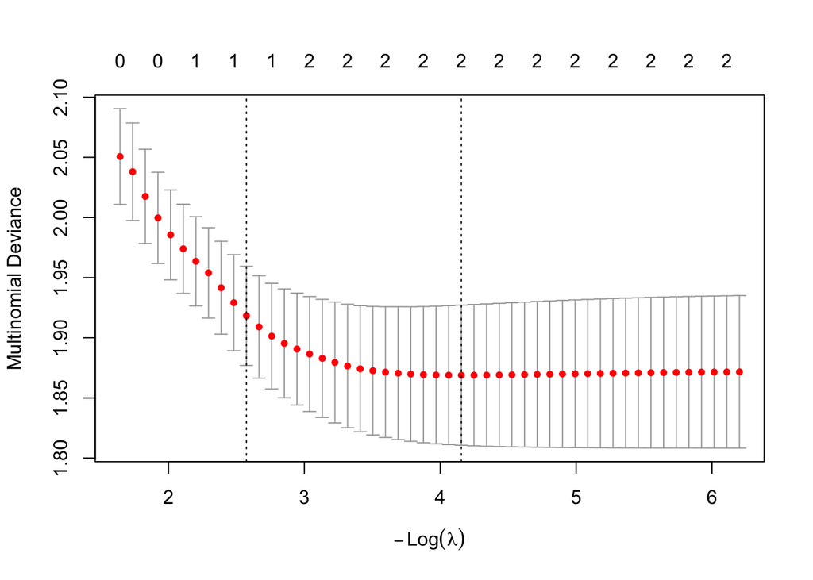

```r
cv.fit <- cv.glmnet(x, y, family = "multinomial")
plot(cv.fit)
```

Now, we can try to predict at the optimal $\lambda$:

```r
predict(cv.fit, newx = x, s = "lambda.min", type = "class")
```

```
##        lambda.min
##   [1,] "vocation"
##   [2,] "vocation"
##   [3,] "academic"
##   [4,] "vocation"
##   [5,] "vocation"
##   [6,] "vocation"
##   [7,] "vocation"
##   [8,] "vocation"
##   [9,] "vocation"
##  [10,] "vocation"
##  [11,] "general"
##  [12,] "vocation"
##  [13,] "vocation"
##  [14,] "vocation"
```

[output cut: 87 more lines]

We might want to see how well we did on the training data.

```r
preds=predict(cv.fit, newx = x, s = "lambda.min", type = "class")
#preds
ind=(preds==y)
mean(ind)
```

```
## [1] 0.6
```